# 3 Data Preparation and Exploration

Published

December 13, 2024

## 3.1 Setting up workspace

#### 3.1.0.1 Loading functions

Some functions we will need in this manuscript.. sourced mainly from Nakagawa 2022 : Online tutorial https://alistairmcnairsenior.github.io/Miss_SD_Sim/

```r
# Function to calculate Geary's "number"
  geary <- function(mean, sd, n){
    (1 / (sd / mean)) * ((4*n^(3/2)) / (1 + 4*n))
  }



# Shinichi Nakagawa, Daniel W. A. Noble, Malgorzata Lagisz, Rebecca Spake, Wolfgang Viechtbauer and Alistair M. Senior. 2022. A robust and readily implementable method for the meta-analysis of response ratios with and without missing standard deviations. Ecology Letters, DOI: 10.1111/ele.14144


  # Functions provided in the workalong
cv_avg <- function(x, sd, n, group, data, label = NULL, sub_b = TRUE, cv2=FALSE){

  # Check if the name is specified or not. If not, then assign it the name of the mean, x, variable input in the function. https://stackoverflow.com/questions/60644445/converting-tidyeval-arguments-to-string
  if(is.null(label)){
    label <- purrr::map_chr(enquos(x), rlang::as_label)
  }

  # Calculate between study CV. Take weighted mean CV within study, and then take a weighted mean across studies of the within study CV. Weighted based on sample size and pooled sample size.
  b_grp_cv_data <- data                                             %>%
    dplyr::group_by({{group}})                            %>%
    dplyr::mutate(   w_CV2 = weighted_CV({{sd}}, {{x}}, {{n}}, cv2=cv2),
                     n_mean = mean({{n}}, na.rm = TRUE))   %>%
    dplyr::ungroup(.)                                     %>%
    dplyr::mutate(b_CV2 = weighted.mean(w_CV2, n_mean, na.rm = TRUE), .keep = "used")

  # Make sure that label of the calculated columns is distinct from any other columns
  names(b_grp_cv_data) <- paste0(names(b_grp_cv_data), "_", label)

  # Append these calculated columns back to the original data and return the full dataset.
  if(sub_b){
    b_grp_cv_data <- b_grp_cv_data %>% dplyr::select(grep("b_", names(b_grp_cv_data)))
    dat_new <- cbind(data, b_grp_cv_data)
  } else {
    dat_new <- cbind(data, b_grp_cv_data)
  }

  return(data.frame(dat_new))
}

# You also need the helper function

weighted_CV <- function(sd, x, n, cv2=FALSE){
  if(cv2){
    weighted.mean(na_if((sd / x)^2, Inf), n, na.rm = TRUE)
  }else{
    weighted.mean(na_if((sd / x), Inf), n, na.rm = TRUE)^2
  }
}


#' @title lnrr_laj
#' @description Calculates log response ratio based on Taylor expansion from Jajeunesse 2011
#' @param m1 Mean of treatment group 1
#' @param m2 Mean of treatment group 2
#' @param cv1_2 Coefficient of variation squared (CV^2) for treatment group 1
#' @param cv2_2 Coefficient of variation squared (CV^2) for treatment group 2
#' @param n1 Sample size for treatment group 1
#' @param n2 Sample size for treatment group 2
#' @param taylor A logical indicating whether to calculate point estimate with Taylor expansion.
#'
lnrr_laj <- function(m1, m2, cv1_2, cv2_2, n1, n2, taylor=TRUE){
  if(taylor){
    log(m1 / m2) + 0.5*((cv1_2 / n1) - (cv2_2 / n2))
  } else {
    log(m1 / m2)
  }
}

#' @title v_lnrr_laj
#' @description Calculates the sampling variance for log response ratio based on second order Taylor expansion proposed by Lajeunesse 2011
#' @param cv1_2 Coefficient of variation squared (CV^2) for treatment group 1
#' @param cv2_2 Coefficient of variation squared (CV^2) for treatment group 2
#' @param n1 Sample size for treatment group 1
#' @param n2 Sample size for treatment group 2
#' @param taylor A logical indicating whether to calculate point estimate with Taylor expansion.
v_lnrr_laj <- function(cv1_2, cv2_2, n1, n2,  taylor=TRUE){
  if(taylor){
  ((cv1_2) / n1) + ((cv2_2) / n2) +
    ((cv1_2)^2 / (2*n1^2)) + ((cv2_2)^2 / (2*n2^2))
  } else {
    ((cv1_2) / n1) + ((cv2_2) / n2)
  }
}
```

### 3.1.1 Excluding proxies that are to be checked

```r
# selecting dataset which are not flagged or to be checked
dataset_analysis<-dataset_after_cleaning%>%
   filter(proxy_decision != "check")

#check what is excluded (as of now 19 rows are excluded)
excluded_rows<- anti_join(dataset_after_cleaning, dataset_analysis)
```

### 3.1.2 Effective Sample Size Calculation

For comparisons involving the shared control or treatment groups across multiple studies, adjusting the sample sizes by dividing them by the number of times each group is included in comparisons. This adjustment helps to prevent any inflation of the effect sizes due to repeated use of the same groups.

```r
dataset_analysis<-dataset_analysis%>%
  mutate(effective_n_experiment=(n_experiment/shared_experiment),.after=n_experiment)%>%
  mutate(effective_n_control=(n_control/shared_control),.after=n_control)
```

Checking the range of effective sample size in our dataset

```r
dataset_analysis%>%
  summarise(control_min=min(effective_n_control,na.rm=T),
            control_max=max(effective_n_control,na.rm=T),
            na_control = sum(is.na(effective_n_control)),
            experiment_min=min(effective_n_experiment,na.rm=T),
            experiment_max=max(effective_n_experiment,na.rm=T),
             na_experiment = sum(is.na(effective_n_experiment)))
```

| control_min | control_max | na_control | experiment_min | experiment_max | na_experiment |
| --- | --- | --- | --- | --- | --- |
| 0.5 | 99 | 3 | 1 | 111 | 3 |

We have some NA and some values of effective sample size 1 and below.. lets see where this is

```r
dataset_analysis%>%
  filter(effective_n_control<2 | effective_n_experiment<2)
```

| paper_ID | fulltext_screening | fulltext_notes | variable_note | authors | year_publication | population_location | Observation_ID | experiment_ID | group_ID | repeated_trait_ID | bird_species | treatment_plant_species | control_plant_species | comparision_type | CH | PCH | Hypothesis | measure_central_tendency_experiment | type_measure_central_tendency_experiment | measure_dispersion_experiment | type_measure_dispersion_experiment | n_experiment | effective_n_experiment | measure_central_tendency_control | type_measure_central_tendency_control | measure_dispersion_control | type_measure_dispersion_control | n_control | effective_n_control | … |
| --- | --- | --- | --- | --- | --- | --- | --- | --- | --- | --- | --- | --- | --- | --- | --- | --- | --- | --- | --- | --- | --- | --- | --- | --- | --- | --- | --- | --- | --- | --- |
| GNM_237 | included | NA | log10, treatment is shared so effective treatment sample size will be divided by 16 | Ruiz-Castellano C.; Tomas G.; Ruiz-Rodriguez M.; Martin-Galvez D.; Soler J. J. | 2016 | Hoya de Guadix, southeast Spain (37°18’N, 3°11’W) | 60 | 2 | 5 | 1 | Sturnus unicolor | Marrubium vulgare, Artemisia barrelieri, Lamium amplexicaule, Anacyclus clavatus | blank | 2 | 0 | 1 | PCH | 1.104134 | mean | 0.4575797 | sd | 2 | 1.0 | 1.241126 | mean | 0.1513146 | sd | 4 | 4.0 | … |
| GNM_237 | included | NA | log10, treatment is shared so effective treatment sample size will be divided by 19 | Ruiz-Castellano C.; Tomas G.; Ruiz-Rodriguez M.; Martin-Galvez D.; Soler J. J. | 2016 | Hoya de Guadix, southeast Spain (37°18’N, 3°11’W) | 61 | 2 | 6 | 1 | Sturnus unicolor | Marrubium vulgare, Artemisia barrelieri, Lamium amplexicaule, Anacyclus clavatus | blank | 2 | 0 | 1 | PCH | 1.259195 | mean | 0.4610955 | sd | 3 | 1.5 | 1.722834 | mean | 0.8657496 | sd | 3 | 3.0 | … |
| GNM_355 | included | NA | Effective treatment sample size shared by 2 Effective control sample size shared by 2 | Clark L; Mason JR | 1988 | SWRC_Philadelphia | 217 | 1 | 3 | 4 | Sturnus vulgaris | Daucus_carota, Erigeron_philadelphicus | grass | 2 | 0 | 1 | PCH | 4.861111 | mean | 0.9820928 | SD | 2 | 1.0 | 4.166667 | mean | 0.7856742 | SD | 2 | 1.0 | … |
| GNM_355 | included | NA | Effective treatment sample size shared by 2 Effective control sample size shared by 2 | Clark L; Mason JR | 1988 | SWRC_Philadelphia | 218 | 1 | 3 | 5 | Sturnus vulgaris | Daucus_carota, Erigeron_philadelphicus | blank | 1 | 0 | 1 | PCH | 4.861111 | mean | 0.9820928 | SD | 2 | 1.0 | 4.861111 | mean | 1.7677670 | SD | 2 | 1.0 | … |
| GNM_355 | included | NA | Effective treatment sample size shared by 2 Effective control sample size shared by 2 | Clark L; Mason JR | 1988 | SWRC_Philadelphia | 219 | 1 | 3 | 6 | Sturnus vulgaris | grass | blank | 3 | 0 | 1 | PCH | 4.166667 | mean | 0.7856742 | SD | 2 | 1.0 | 4.861111 | mean | 1.7677670 | SD | 2 | 1.0 | … |
| GNM_355 | included | NA | Effective treatment sample size shared by 2 Effective control sample size shared by 2 | Clark L; Mason JR | 1988 | SWRC_Philadelphia | 220 | 1 | 3 | 4 | Sturnus vulgaris | Daucus_carota, Erigeron_philadelphicus | grass | 2 | 0 | 1 | PCH | 12.222222 | mean | 1.9245009 | SD | 3 | 1.5 | 10.555556 | mean | 0.5555556 | SD | 4 | 2.0 | … |
| GNM_355 | included | NA | Effective treatment sample size shared by 2 Effective control sample size shared by 2 | Clark L; Mason JR | 1988 | SWRC_Philadelphia | 221 | 1 | 3 | 5 | Sturnus vulgaris | Daucus_carota, Erigeron_philadelphicus | blank | 1 | 0 | 1 | PCH | 12.222222 | mean | 1.9245009 | SD | 3 | 1.5 | 12.222222 | mean | 1.1785113 | SD | 2 | 1.0 | … |
| GNM_355 | included | NA | Effective treatment sample size shared by 2 Effective control sample size shared by 2 | Clark L; Mason JR | 1988 | SWRC_Philadelphia | 222 | 1 | 3 | 6 | Sturnus vulgaris | grass | blank | 3 | 0 | 1 | PCH | 10.555556 | mean | 0.5555556 | SD | 4 | 2.0 | 12.222222 | mean | 1.1785113 | SD | 2 | 1.0 | … |
| GNM_355 | included | NA | Effective treatment sample size shared by 2 Effective control sample size shared by 2 | Clark L; Mason JR | 1988 | SWRC_Philadelphia | 223 | 1 | 3 | 4 | Sturnus vulgaris | Daucus_carota, Erigeron_philadelphicus | grass | 2 | 0 | 1 | PCH | 15.000000 | mean | 1.1111111 | SD | 4 | 2.0 | 11.944444 | mean | 0.4811252 | SD | 3 | 1.5 | … |
| GNM_355 | included | NA | Effective treatment sample size shared by 2 Effective control sample size shared by 2 | Clark L; Mason JR | 1988 | SWRC_Philadelphia | 224 | 1 | 3 | 5 | Sturnus vulgaris | Daucus_carota, Erigeron_philadelphicus | blank | 1 | 0 | 1 | PCH | 15.000000 | mean | 1.1111111 | SD | 4 | 2.0 | 15.000000 | mean | 0.4811252 | SD | 3 | 1.5 | … |

[output cut: 19 more lines]

Many of these data points come from GNM_355. There are datapoints with sample size of 1 for some groups. We have extracted data by days and months.. I will combine these for this paper because of such low sample size. (We cannot estimate SMHD with 0.5 as an effective sample size)

### 3.1.3 Converting variance to SD

There were no other measure of dispersion, only SE and SD, so no need to convert anything more.

```r
## Calculating sd from difference variance measures (only for se so far)

# For experimental group
dataset_analysis <- dataset_analysis %>%
  mutate(sd_experiment = if_else(type_measure_dispersion_experiment %in% c('se', 'SE'), #condition to check
      measure_dispersion_experiment * sqrt(as.numeric(n_experiment)), # do this if true
      measure_dispersion_experiment), #else do this
      .after=measure_dispersion_experiment)
# For control group
dataset_analysis <- dataset_analysis %>%
  mutate(sd_control = if_else(type_measure_dispersion_control %in% c('se', 'SE'), #condition to check
      measure_dispersion_control* sqrt(as.numeric(n_control)), # do this if true
      measure_dispersion_control), #else do this
      .after=measure_dispersion_control)
```

Some checks for the value of mean and SD

```r
# Some rows contain NAs, check why
# contains_NA<-dataset_analysis%>%
# filter(is.na(measure_central_tendency_experiment)|is.na(measure_dispersion_experiment))

# 13 rows contain NA and I checked them manually, everything looks okay.
# - 4 rows contain only statistical test values and
# - 9 are missing data that authors did not provide for which we will use 0 as effect size.
```

### 3.1.4 Preparing Random Effects

We will include the following random effects in all our models unless stated otherwise:

- (1) paper_ID, which encompasses estimates extracted from the same primary study
- (2) experiment_ID
- (3) group_ID
- (4) repeated_traits_ID
- (5) observation_ID,

which corresponds to a unit-level observation identity and models within-study variance (for more details on the selection of random effects (see Section Miscellaneous synthesis details).

```r
dataset_analysis<-dataset_analysis%>%
  mutate(Observation_ID = as.factor(row_number()))%>%
  mutate(experiment_ID_coded = as.factor(paste(paper_ID, experiment_ID, sep="_")),.after=experiment_ID)%>%
  mutate(group_ID_coded = as.factor(paste(paper_ID, group_ID, sep="_")),.after=group_ID)%>%
  mutate(repeated_trait_ID_coded = as.factor(paste(paper_ID,group_ID, repeated_trait_ID, sep="_")),.after=repeated_trait_ID)

# random_effects_check<-dataset_analysis%>%select(paper_ID,experiment_ID,group_ID,repeated_trait_ID, experiment_ID_coded,group_ID_coded, repeated_trait_ID_coded)

# write.csv(dataset_analysis,file=here::here("data/input/dataset_analysis.csv"),row.names = FALSE)
```

## 3.2 Effect Size Estimation

### 3.2.1 Geary’s Test

```r
# Assumption of normality assumed to be approximately correct when values are >= 3.
dataset_analysis<- dataset_analysis %>%
         mutate(geary_control = geary(measure_central_tendency_control,
                                      sd_control,
                                      n_control),
                    geary_trt = geary(measure_central_tendency_experiment,
                                      sd_experiment,
                                      n_experiment),
                   geary_test = ifelse(geary_control >= 3 & geary_trt >= 3, "pass", "fail"))

# How many fail?
    geary_res <-dataset_analysis %>% group_by(geary_test) %>% summarise(n = n()) %>%  data.frame()

    geary_res
```

| geary_test | n |
| --- | --- |
| fail | 51 |
| pass | 234 |
| NA | 20 |

### 3.2.2 No effect size provided

We will calculate the mean trait values by group (for now I use the mean of both experimental and control group, we can change it later if we want but since I only needed one value, this was good.

```r
# To calculate means by groups
trait_mean<- dataset_analysis%>%group_by(trait_type)%>%
  summarise(
    cumulative_mean = mean (
      c(measure_central_tendency_experiment,measure_central_tendency_control),
      na.rm=T
    ),
    count = n()
  )%>%
  arrange(desc(count))

# Now I need to assign the mean values from this to the missing ES proxies
dataset_analysis<-dataset_analysis%>%
  left_join(trait_mean, by= "trait_type")%>%
  mutate(measure_central_tendency_experiment = if_else((
    proxy_comment == "use 0 as ES" & !is.na(proxy_comment)),
    cumulative_mean,
    measure_central_tendency_experiment),
    measure_central_tendency_control = if_else((
    proxy_comment == "use 0 as ES" & !is.na(proxy_comment)),
    cumulative_mean,
    measure_central_tendency_control),)%>%
  select(-cumulative_mean)
```

```r
# Using missing-cases method approach as suggested by Nakagawa 2022 : Online tutorial -
#  https://alistairmcnairsenior.github.io/Miss_SD_Sim/

# First calculate CV on missing data set. Note missing data will be ignored
    dataset_analysis <- dataset_analysis %>%
      mutate(cv_Control = na_if(sd_control/measure_central_tendency_control, Inf),
             cv_Experimental = na_if(sd_experiment/measure_central_tendency_experiment, Inf))

# Calculate the average between study CV, which will replace missing values.
    dataset_analysis <- cv_avg(x = measure_central_tendency_experiment,
                                sd = sd_experiment,
                            n = effective_n_experiment,
                            group = paper_ID,
                            label = "1",
                             data = dataset_analysis)
    dataset_analysis <- cv_avg(measure_central_tendency_control,
                                sd = sd_control,
                            n = effective_n_control,
                            group = paper_ID,
                            label = "2",
                             data = dataset_analysis)


# Use weighted mean CV in replacement for where CV's are missing. Otherwise, calculate CV^2 of data that is known.
   dataset_analysis  <- dataset_analysis %>%
              mutate(cv2_cont_new = if_else(is.na(cv_Control),      b_CV2_2, cv_Control^2),
                     cv2_expt_new = if_else(is.na(cv_Experimental), b_CV2_1, cv_Experimental^2))

# Now calculate new yi and vi, called lnrr_laj & v_lnrr_laj, respectively. This uses either the between individual CV^2 when missing or normal CV^2 when not missing.
    dataset_analysis  <- dataset_analysis %>%
              mutate(lnrr_laj = lnrr_laj(m1 = measure_central_tendency_experiment,
                                         m2 = measure_central_tendency_control,
                                         cv1_2 = cv2_expt_new, cv2_2 = cv2_cont_new,
                                         n1= effective_n_experiment,
                                         n2 = effective_n_control),
                   v_lnrr_laj = v_lnrr_laj(cv1_2 = cv2_expt_new,
                                           n1= effective_n_experiment,
                                           cv2_2 = cv2_cont_new,
                                           n2 = effective_n_control))


# We have added 16 zeros to the dataset
#
# dataset_zeroES<-dataset_analysis %>%
#   filter(proxy_comment == "use 0 as ES" & !is.na(proxy_comment))
```

# 4 Calculate lnRR

‘escalc()’ (with measure=ROM and ‘vtype=LS’

Since lnRR can only be calculated for ratio scale data (i.e., data with a true zero; among other assumptions), we will exclude effect sizes with a negative value when calculating lnRR.

```r
dataset_lnRR<-dataset_analysis

#check what is excluded i.e. flagged or for SMDH only (as of now 22 rows are excluded)
# excluded_rows<- anti_join(dataset_analysis, dataset_lnRR)


# selecting dataset where the values of are negative for mean i.e. not ratio scale data
dataset_lnRR<-dataset_lnRR%>%
  filter(measure_central_tendency_experiment>=0 | is.na(measure_central_tendency_experiment))%>%
  filter(measure_central_tendency_control>=0 | is.na(measure_central_tendency_experiment))

#check what is excluded, 7 values that have a negative mean/SD
# excluded_rows <- anti_join(dataset_analysis, dataset_lnRR)
# check GNM_069 telomere dynamic


dataset_lnRR<- escalc(measure = "ROM",
              vtype= "LS",
                        n1i = effective_n_experiment,
                        n2i = effective_n_control,
                        m1i = measure_central_tendency_experiment,
                        m2i = measure_central_tendency_control,
                        sd1i = sd_experiment,
                        sd2i = sd_control,
                        data = dataset_lnRR,
                        var.names = c('lnRR',
                                      'lnRR_variance'),
                        add.measure = FALSE,
                        append = TRUE)


# I am going to assign the values of missing lnRR and lnRR_variance for the ones where the data was missing but use the one calculated from escalc in all other cases because I am not 100% sure the method of calculation in Nakagawa 2022 function provided.

# Now I need to assign the mean values from this to the missing ES proxies
dataset_lnRR<-dataset_lnRR%>%
  mutate(lnRR = if_else((
    proxy_comment == "use 0 as ES" & !is.na(proxy_comment)),
    lnrr_laj,
    lnRR),
   lnRR_variance = if_else((
    proxy_comment == "use 0 as ES" & !is.na(proxy_comment)),
    v_lnrr_laj,
    lnRR_variance),)%>%
  select(-c(v_lnrr_laj,lnrr_laj,cv2_expt_new,cv2_cont_new,b_CV2_2,b_CV2_1,cv_Experimental,cv_Control))

dataset_analysis<-dataset_analysis%>%
    select(-c(v_lnrr_laj,lnrr_laj,cv2_expt_new,cv2_cont_new,b_CV2_2,b_CV2_1,cv_Experimental,cv_Control))
```

### 4.0.1 Sign for Effect Size

- For both lnRR and SMDH, we will ensure throughout the dataset that positive values mean higher estimates of fitness in the experimental group compared to their control counterparts by multiplying all the effect sizes by their corresponding sign, i.e., by -1 or +1.

```r
dataset_lnRR<-dataset_lnRR%>%
  mutate(lnRR_sign=lnRR*proxies_sign)
```

### 4.0.2 Outliers Check

We do not plan to exclude any outliers as long as the extracted data is seemingly correct.

Now let’s plot means and SD to see everything looks okay

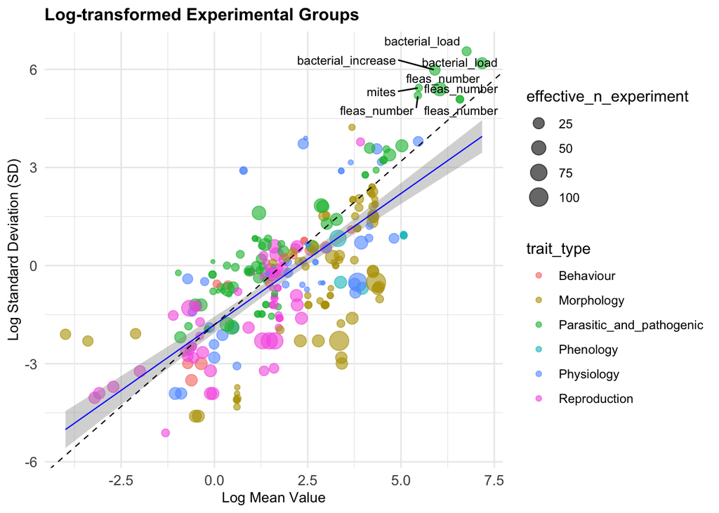

```r
## We have to exclude the datapoints where we do not have dispersion value. We have added 0 ES in some cases and this is not allowing the lm line to be plotted
#
temp_data<-dataset_lnRR%>%
  filter(proxy_comment == "use 0 as ES" & !is.na(proxy_comment))
dataset_lnRR_plot<-anti_join(dataset_lnRR,temp_data)

 outliers_experiment<- dataset_lnRR %>%
  filter(measure_dispersion_experiment>100)
 outliers_control<- dataset_lnRR %>%
  filter(measure_dispersion_control >100)


# For experimental group

# Fit a linear model to extract the intercept
lm_fit_experiment <- lm(log(measure_dispersion_experiment) ~
                          log(measure_central_tendency_experiment),
                        data = dataset_lnRR_plot)
intercept_value_experiment <- coef(lm_fit_experiment)[1] # Extract the intercept

lm_fit_control <- lm(log(measure_dispersion_control) ~
                       log(measure_central_tendency_control),
                     data = dataset_lnRR_plot)
intercept_value_control <- coef(lm_fit_control)[1]

# Scatter plot of means vs SDs for experimental group
dataset_lnRR_plot %>%
  ggplot(aes(x = log(measure_central_tendency_experiment),
             y = log(measure_dispersion_experiment),
             size = effective_n_experiment,
             colour = trait_type)) +
  geom_point(alpha = 0.6) +
  geom_text_repel(
    data = outliers_experiment,
    aes(
      x = log(measure_central_tendency_experiment),
      y = log(measure_dispersion_experiment),
      label = fitness_proxy_cleaned
    ),
    size = 3, color = "black", max.overlaps = 15
  ) +
  geom_smooth(
    method = "lm",  # Adds a regression line
    se = TRUE,      # Adds confidence intervals
    color = "blue", # Color of the line
    linetype = "solid",# Style of the line
    size = 0.4
    ) +
  # Add a line representing correlation of 1
  geom_abline(
    slope = 1,       # Slope of the line
    intercept = intercept_value_experiment,   # Intercept of the line
    color = "black", # Color of the line
    linetype = "dashed", # Style of the line
    size = 0.4       # Thickness of the line
  )+
  labs(
    x = "Log Mean Value",
    y = "Log Standard Deviation (SD)",
    title = "Log-transformed Experimental Groups"
  ) +
  theme_minimal() +
  theme(
    plot.title = element_text(size = 12, face = "bold"),
    axis.title = element_text(size = 10),
    axis.text = element_text(size = 10)
  )
```

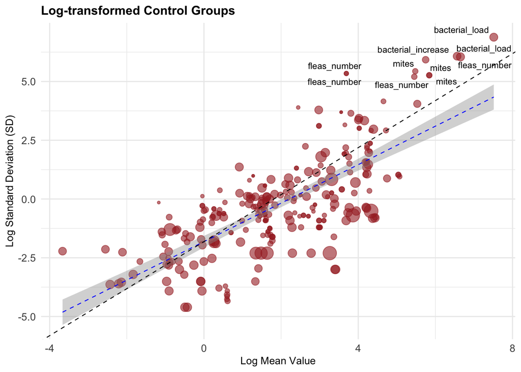

```r
# For Control group

# Scatter plot of means vs SDs for experimental group
dataset_lnRR_plot %>%
  ggplot(aes(x = log(measure_central_tendency_control),
             y = log(measure_dispersion_control),
             size = effective_n_control)) +
  geom_point(color = "brown", alpha = 0.6) +
  geom_text_repel(
    data = outliers_control,
    aes(
      x = log(measure_central_tendency_control),
      y = log(measure_dispersion_control),
      label = fitness_proxy_cleaned
    ),
    size = 3, color = "black", max.overlaps = 15
  ) +
  geom_smooth(
    method = "lm",  # Adds a regression line
    se = TRUE,      # Adds confidence intervals
    color = "blue", # Color of the line
    linetype = "dashed", # Style of the line
    size= 0.4
    ) +
  # Add a line representing correlation of 1
  geom_abline(
    slope = 1,       # Slope of the line
    intercept = intercept_value_control,   # Intercept of the line
    color = "black", # Color of the line
    linetype = "dashed", # Style of the line
    size = 0.4       # Thickness of the line
  )+
  labs(
    x = "Log Mean Value",
    y = "Log Standard Deviation (SD)",
    title = "Log-transformed Control Groups"
  ) +
  theme_minimal() +
  theme(
    plot.title = element_text(size = 12, face = "bold"),
    axis.title = element_text(size = 10),
    axis.text = element_text(size = 10),
    legend.position = "none"
  )
```